# Analysing an A/B Experiment

Marcel Aguilar Garcia, id=20235620

07 November, 2021

**A company is interested in investigating whether adding a new variant to a particular website will improve i) the visit through time and ii) the proportion of query items resolved compared to that observed in the current website.**

A sample of 200 customers were directed to either the current or new variant of the website and their visit through time whether or not their query was resolved was recorded.

```r
library(table1)
library(dplyr)
library(ggplot2)
options(rgl.useNULL = TRUE)
library(rgl)
library(tolerance)
library(infer)
library(ggridges)
library(viridis)
```

Let’s start loading the data into a dataframe. Additionally, I define two dataframes with the data of each of the variants, A (df_A), and B (df_B).

```r
df <- read.csv('ab_test.csv')

df <- df %>%
  mutate(Resolved.num =
           case_when(
           Resolved == 'Yes' ~ 1,
           Resolved == 'No'~0))

df_A = df %>% filter(Variant == 'A')
df_B = df %>% filter(Variant == 'B')
```

In order to have a better idea of which distribution variable Time follows for each variant, we can create a histogram of the variable Time for Variant A and Variant B.

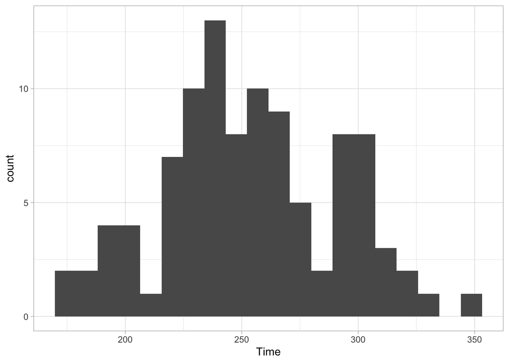

```r
ggplot(df_A, aes(x=Time)) + geom_histogram(bins=20)+
  theme_light()
```

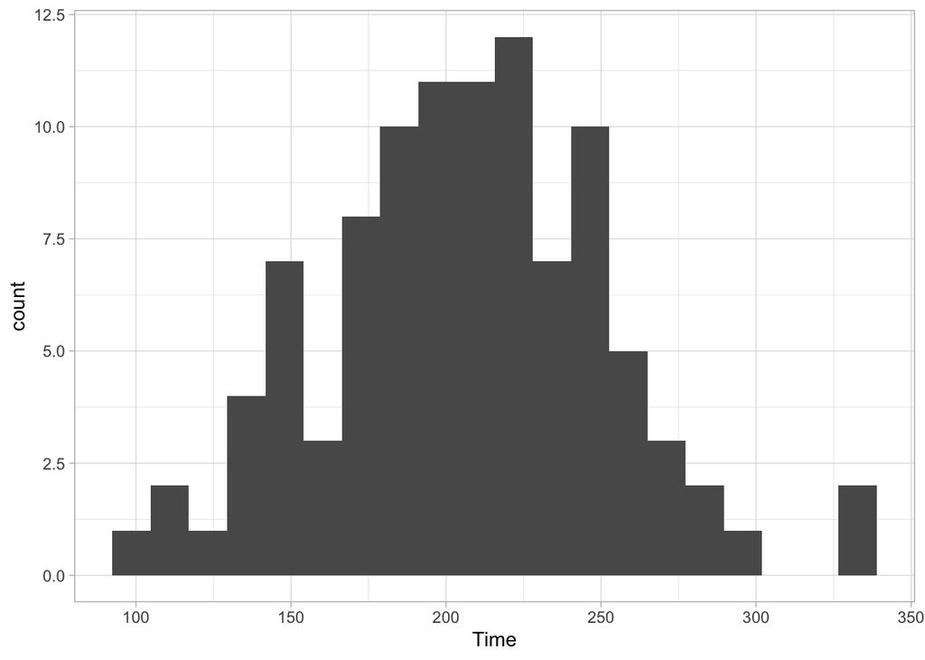

```r
ggplot(df_B, aes(x=Time)) + geom_histogram(bins=20)+
  theme_light()
```

By looking at the histograms, it seems that Time follows a Normal Distribution in both cases. Additionally, we can perform Shapiro-Wilk’s test:

```r
shapiro.test(df_A$Time)
```

```
##
##  Shapiro-Wilk normality test
##
## data:  df_A$Time
## W = 0.98685, p-value = 0.4275
```

```r
shapiro.test(df_B$Time)
```

```
##
##  Shapiro-Wilk normality test
##
## data:  df_B$Time
## W = 0.99172, p-value = 0.8004
```

As p-value > 0.05, we can assume in both cases that the distribution of the data is not significantly different from normal distribution.

On top of that, we can assume that the samples are independent of each other as, e.g, knowing the time that it took to one user to go through the website tells you nothing of another user.

You are asked to use these data estimate the probability that:  
1. a random customer will have a visit through time on the new site of less than 2 minutes;  
2. at least 60% of queries on the new site will be resolved in a day where it is assumed that 50 customers visit the site in a day.

We would like to first calculate the probability of a random customer having a visit through time on the new site of less than two minutes. As we are now assuming normality for Time, we can calculate the probability by using the distribution function in R.

```r
pnorm(q=120, mean = mean(df_B$Time) , sd = sd(df_B$Time), lower.tail = TRUE)
```

```
## [1] 0.02830364
```

This means that the probability of a random customer having a visit through time on the new site of less than two minutes is 0.028.

Now, let’s calculate the probability that at least 60% of queries on the new site will be resolved in a day where it is assumed that 50 customers visit the site in a day. The proportion of queries that are resolved in the new website is p = 49/100 = 0.49, on the other hand we would like to calculate the probability that more than 0.6x50 = 30 queries are resolved on that day. In this case, Resolved follows a binomial distribution Bi(50,0.49). Therefore we can calculate this in R by using the cumulative probability function pbinom:

```r
pbinom(50*0.6,50,0.49, lower.tail = FALSE)
```

```
## [1] 0.04447681
```

This means that the probability of oberving more than 60% of queries in a day that there are 50 customers visiting the new website is of 0.045.

**You are also asked to provide a comprehensive analysis of these data to decide whether the new site is better than the current site in terms of an improved (average) visit through time and proportion of query items resolved.**

In your report you must address the following points:  
1. Describe the design used.  
2. Outline any concerns might you have with the design used.  
3. Provide suitable numerical and graphical summaries.  
4. Provide the results of a suitable formal analysis (hypothesis test and interval estimate) for both response variables.  
5. Calculate and interpret a 95%/95% Tolerance Interval for the visit through time variable.  
6. Make a conclusion as to whether the change should be made to the current website.

The technique that I will be using is A/B Testing. This methodology compares the user experience of a product with two different variants (designs/features). In order to do this, I will be using statistic techniques such as statistical hypothesis testing to compare which website has, in average, better visits through time, and which one resolves more queries.

Let’s first focus on analyzing Time. We can start by checking the mean and start deviation for time for both variants as seen below:

```r
table1(~ Time  | Variant, df)
```

|  | A (N=100) | B (N=100) | Overall (N=200) |
| --- | --- | --- | --- |
| Time |  |  |  |
| Mean (SD) | 254 (37.4) | 206 (45.0) | 230 (47.7) |
| Median [Min, Max] | 251 [173, 348] | 206 [98.4, 333] | 232 [98.4, 348] |

We can see that the new website (Variant B), has lower mean and median, when comparing to the current website (Variant A). While there is yet no evidence, it seems that the new variant may improve the visit through time. Visually, we can use a boxplot or ridgeline plots to support this statement:

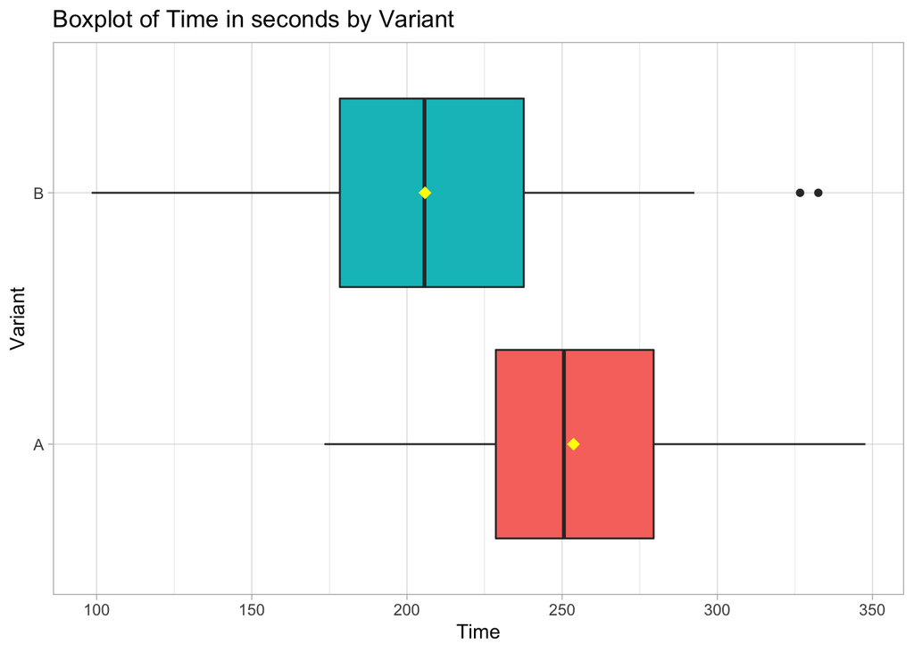

```r
df %>%
ggplot(aes(x=Time, y=Variant, fill=Variant)) +
  geom_boxplot() +
  stat_summary(fun=mean, colour="yellow", geom="point",
               shape=18, size=3) +
    labs(title="Boxplot of Time in seconds by Variant") +
  theme_light()+
  theme(legend.position = "none")
```

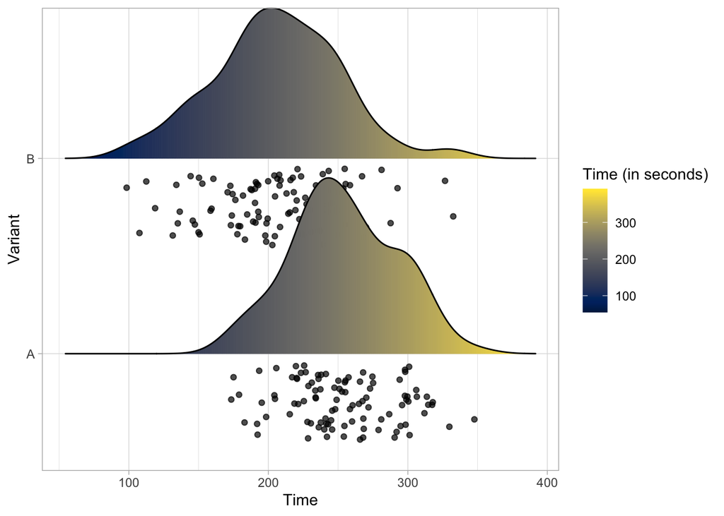

```r
df %>%
ggplot(aes(x=Time, y=Variant, fill=..x..)) +
geom_density_ridges_gradient(jittered_points=TRUE,position="raincloud",alpha=0.7,scale=0.9)+
  scale_fill_viridis(name="Time (in seconds)",option = "E")+
  theme_light()
```

We can now consider the random variable given by the difference of Time in variant A and Time in variant B. As we assume normality for both of these variables, we can perform a two sample t-test to obtain a confidence interval of this difference:

```r
t.test(Time~Variant,data=df, conf.level = 0.95)
```

```
##
##  Welch Two Sample t-test
##
## data:  Time by Variant
## t = 8.178, df = 191.55, p-value = 3.9e-14
## alternative hypothesis: true difference in means is not equal to 0
## 95 percent confidence interval:
##  36.31417 59.39891
## sample estimates:
## mean in group A mean in group B
##        253.6713        205.8147
```

As we have not specified the order, this difference is calculated as time in Variant A minus time in Variant B. The fact that zero is not in the confidence interval means that there is evidence that the new website (Variant B) improves the visit through time. In particular, we can say that Variant B improves the time, in average, by between 36.31 and 59.40 seconds.

Finally, we can calculate the 95%/95% Tolerance Interval of both variants:

```r
normtol.int(df_A$Time,alpha = 0.05, P=0.95,side=2)
```

| alpha | P | x.bar | 2-sided.lower | 2-sided.upper |
| --- | --- | --- | --- | --- |
| 0.05 | 0.95 | 253.6713 | 170.1456 | 337.1969 |

From this result, we can say that it is likely that 95% of users that use the current website will have times between 170.15s and 337.20s.

```r
normtol.int(df_B$Time,alpha = 0.05, P=0.95,side=2)
```

| alpha | P | x.bar | 2-sided.lower | 2-sided.upper |
| --- | --- | --- | --- | --- |
| 0.05 | 0.95 | 205.8147 | 105.2545 | 306.3749 |

From this result, we can say that it is likely that 95% of users that use the new website will have times between 105.25s and 306.37s.

We can now start our analysis for variable Resolved. The aim is to investigate whether by changing the current website to the new one will improve the proportion of resolved cases.

We can start by generating the table of frequencies for each variant:

```r
table1( ~Resolved| Variant, data=df)
```

|  | A (N=100) | B (N=100) | Overall (N=200) |
| --- | --- | --- | --- |
| Resolved |  |  |  |
| No | 48 (48.0%) | 51 (51.0%) | 99 (49.5%) |
| Yes | 52 (52.0%) | 49 (49.0%) | 101 (50.5%) |

This table suggests that the new variant may end up with less queries being resolved but the difference is very small. While it is not easy to see the difference, this proportions can be visualised in the stacked barplot below:

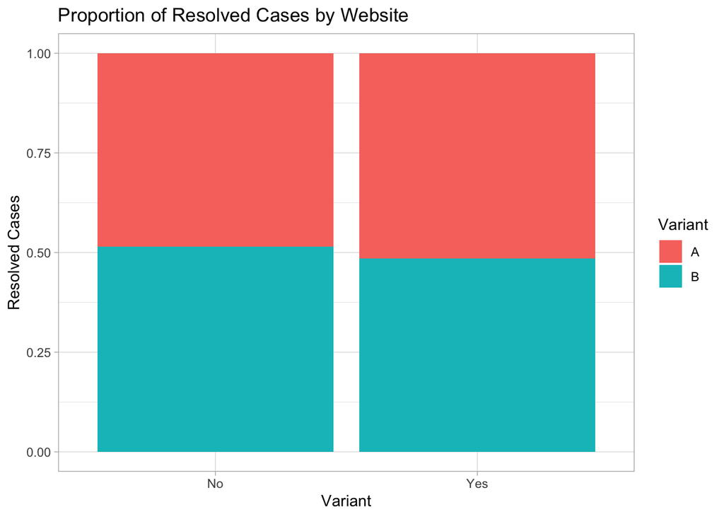

```r
df %>%
  ggplot() +
   geom_bar(aes(Resolved, fill = Variant),
            position = "fill") +
  labs(y = "Resolved Cases",
       x = "Variant",
       title = "Proportion of Resolved Cases by Website")+
    theme_light()
```

As the current proportion of resolved queries that happened in the current version of the website is 52/100 = 0.52. We can calculate the corresponding 95% CI for the proportion of resolved cases in Variant A as:

```r
prop.test(x=52, n=100, conf.level = 0.95)
```

```
##
##  1-sample proportions test with continuity correction
##
## data:  52 out of 100, null probability 0.5
## X-squared = 0.09, df = 1, p-value = 0.7642
## alternative hypothesis: true p is not equal to 0.5
## 95 percent confidence interval:
##  0.4183183 0.6201278
## sample estimates:
##    p
## 0.52
```

From this, we can conclude that the proportion of users that are able to resolve a query in the current website is between 0.42 and 0.62.

In a similar way, the proportion of resolved queries for the new website is 49/100 = 0.49. We can then calculate the corresponding 95% CI for the proportion of resolved cases as:

```r
prop.test(x=49, n=100, conf.level = 0.95)
```

```
##
##  1-sample proportions test with continuity correction
##
## data:  49 out of 100, null probability 0.5
## X-squared = 0.01, df = 1, p-value = 0.9203
## alternative hypothesis: true p is not equal to 0.5
## 95 percent confidence interval:
##  0.3894281 0.5913488
## sample estimates:
##    p
## 0.49
```

From this, we can conclude that the proportion of users that are able to resolve a query in the new website is between 0.39 and 0.59

However, when considering the difference of proportions between variant A and B, we find out that:

```r
prop.test(x = c(52, 49), n = c(100, 100),
          alternative = "two.sided",
          conf.level = 0.95)
```

```
##
##  2-sample test for equality of proportions with continuity correction
##
## data:  c(52, 49) out of c(100, 100)
## X-squared = 0.080008, df = 1, p-value = 0.7773
## alternative hypothesis: two.sided
## 95 percent confidence interval:
##  -0.1185211  0.1785211
## sample estimates:
## prop 1 prop 2
##   0.52   0.49
```

As p > 0.05 there is not enough evidence to conclude that there is a significant difference of resolved cases proportions between both variants.

## Conclusion

We have shown evidence that the new variant improves the times by 36.31 and 59.40 seconds. Additionally, while in the sample population, the current website has a proportion of resolved queries slightly higher, we have seen that there is no evidence to conclude that there is a significant difference of proportion of resolved queries between the current website and the new website. For this reason, I would recommend using the new variant.